# Lake Mixing Module - Making a heat map or isopleth of lake temperature depth and time

# Making of an isopleth plot of lake temperature with depth and time

Note that this is a modification of a GLEON workshop presented at Mohonk Perserve buy the students from Miami University.

## Install Packages

```r
# install.packages("tidyverse") # the digitty of packages that makes it all work
# install.packages("lubridate") # works with dates
# install.packages("scales") # used for the x and y axis scales
# install.packages("colorRamps") # makes color palettes like Matlab used in the heatplot
# install.packages("akima") # this does interpolation of data for the heatplot
```

## Load libraries

```r
library(tidyverse)
library(readxl)
library(lubridate)
library(scales)
library(colorRamps)
library(akima)
```

## Read in the data

```r
annie.df <- read_excel("../data/lake_mixing_module_dataset.xlsx",
                         # identifies the file to read in
  sheet="Annie", # identifies the sheet to read in
  guess_max = 1000, # allows more rows to guess the type of data
  skip = 1) # skips the first row of data
```

## Clean Data

Because the icopleth plot does not need st, airt, or windsp these are removed

```r
annie.df <- annie.df %>%
  select(-st, -airt, -windsp) # this removes the columns using the - in front of the variable
```

## Change format of the datframe to a long format to do interpolations

This is a rather cool way to make the data format change so there is a column of datetime, depth and wtemp from what is considered a wide formate where there is date time, and depth goes across the top.

```r
annie_long.df <- annie.df %>%
  gather(depth, wtemp, -datetime)
```

## Clean up long format data

Note that depth is considered a character and this need to be numeric.

```r
annie_long.df <- annie_long.df %>%
  mutate(depth = as.numeric(depth)) # changes the depth to a numeric format
```

## Clean up bad data and out of range data

```r
annie_long.df <- annie_long.df %>% # use this df for rest of commands
  filter(wtemp>=0) %>% # select data that is greater or equal to 0
  filter(!is.na(wtemp)) %>% # remove all NA values
  select(datetime, depth, wtemp) # this uses only the variables that are needed
```

## Create daily temperture averages to make plotting faster

```r
annie_long.df <- annie_long.df %>% # use this df for rest of commands
  mutate(date = as.Date(datetime)) %>%
  select(-datetime) %>%
  group_by(date, depth) %>%
  summarize(wtemp = mean(wtemp, na.rm = TRUE))
```

## interolated watertemp with depth

jsut a note here that the x interpretation step of 1 works with day data as it is using the number of days. The issue comes up when you want to use time. The thing to remember here is time in R is the number of seconds since 1970-01-01 00:00:00 so if you do hours you would use 3600 seconds rather than 1

Note that this is really slow to do this much work

```r
annie_interp.df <- interp(x = annie_long.df$date,
                            y = annie_long.df$depth,
                            z = annie_long.df$wtemp,
                            xo = seq(min(annie_long.df$date), max(annie_long.df$date), by = 1),
                            yo = seq(min(annie_long.df$depth), max(annie_long.df$depth), by = 0.2),
                            extrap=FALSE,
                            linear=TRUE)
```

## Convert interpolated data into a dataframe

```r
annie_interp.df <- interp2xyz(annie_interp.df, data.frame = TRUE)
```

## Clean up dates using dplyr

```r
annie_interp.df <- annie_interp.df %>%
  mutate(date = as_date(x)) %>% # interp turned dates into integers and this converts back
  mutate(day = day(date)) %>% # create day varaible for plotting
  mutate(year = year(date)) %>% # create a four digit year column
  select(-x) %>% #remove x column
  rename(depth=y, wtemp=z) #rename variables
```

# Plot interpolated data

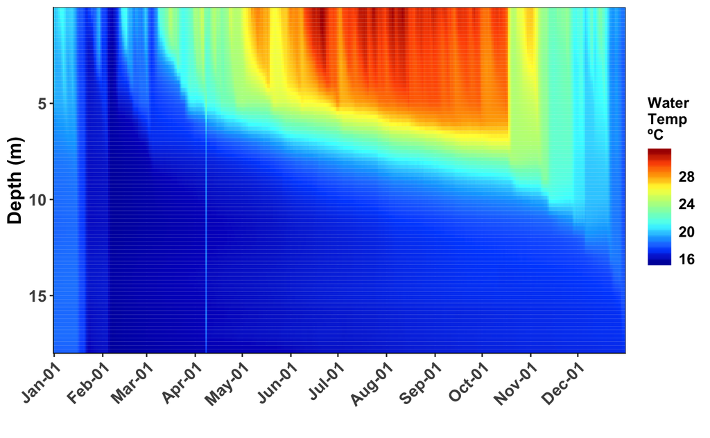

```r
heatmap.plot <- annie_interp.df %>%
  ggplot(aes(x = date, y = depth, z = wtemp, fill = wtemp)) +
  geom_tile() + # used to use geom_raster
  scale_y_reverse(expand=c(0,0)) +
  scale_fill_gradientn(colours=matlab.like(10),
                       na.value = 'gray', name="Water\nTemp \nºC") +
  scale_x_date(date_breaks = "1 month",
               # limits = as_date(c('2016-12-06','2017-02-25')),
               labels=date_format("%b-%d"), expand=c(0,0)) +
  ylab("Depth (m)") +
  xlab("") +
  guides(fill = guide_colorbar(ticks = FALSE)) +
  theme(
    # LABLES APPEARANCE
    axis.title.x=element_text(size=14, face="bold"),
    axis.title.y=element_text(size=14, face="bold"),
    axis.text.x = element_text(size=12, face="bold", angle=45, hjust=1),
    axis.text.y = element_text(size=12, face="bold"),
    # plot.title = element_text(hjust = 0.5, colour="black", size=22, face="bold"),
    # LEGEND
    # LEGEND TEXT
    legend.text = element_text(colour="black", size = 11, face = "bold"),
    # LEGEND TITLE
    legend.title = element_text(colour="black", size=11, face="bold"),
    # ADD AXES LINES AND SIZE
    axis.line.x = element_line(color="black", size = 0.3),
    axis.line.y = element_line(color="black", size = 0.3),
    # ADD PLOT BOX
    panel.border = element_rect(colour = "black", fill=NA, size=0.3))
heatmap.plot
```

# Save the plot

```r
ggsave(heatmap.plot,
       file="../figures/lake annie heatmap.pdf",
       width=7.5,
       height=7.5,
       units = "in")
```